# Study 1: OpenAlex Mean Citedness as a Proxy for Traditional Journal Metrics

We first tested whether OpenAlex’s mean citedness can serve as a reliable proxy for more established journal-level impact metrics since we wanted to rely on openly available and non-commercial data. If OpenAlex mean citedness tracks traditional metrics closely, it can be used with confidence in place of these proprietary indicators. This study was exploratory and not preregistered.

## Method

We compared OpenAlex mean citedness against two established journal-level metrics: the Scimago Journal Rank (SJR), an openly available indicator conceptually similar to the JIF, and the Scimago “Citations per Document (2 years)” measure, which mirrors the JIF’s two-year citation window. Journal-level OpenAlex mean citedness values were merged with the 2024 Scimago dataset by journal title, retaining only journals for which both sources provided data. Because the distributions of all three metrics are highly skewed, we assessed associations using Spearman rank correlations.

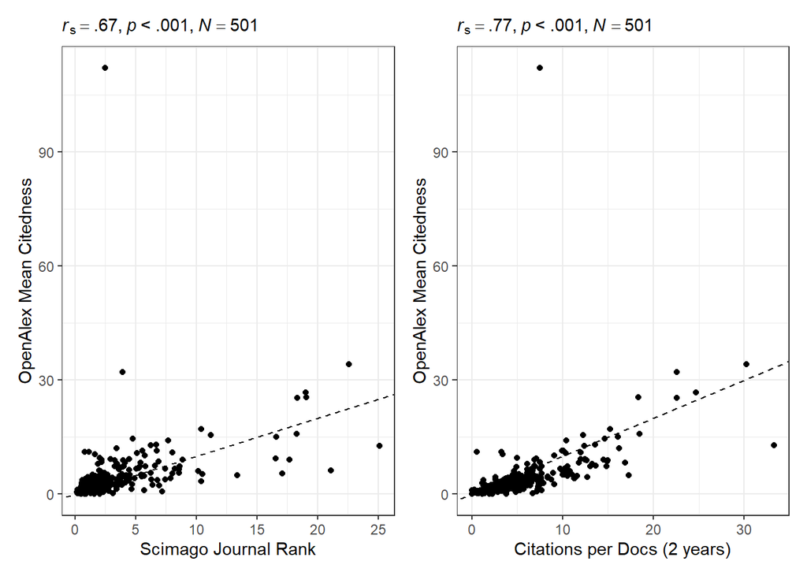

## Discussion

To summarize, OpenAlex mean citedness aligns closely with established journal-level impact indicators, showing strong rank-order agreement with both the Scimago Journal Rank and Scimago’s two-year citations-per-document measure. This supports the use of OpenAlex mean citedness as an open, freely accessible proxy for traditional metrics such as the JIF. Given this correspondence, we rely on OpenAlex mean citedness in the following study, where openness and reproducibility of the data source are essential.